# Smart Action Project

### 🌱 Smart Action – Business Summary

Smart Action is a consulting initiative designed to promote sustainable tourism by helping tourist accommodations in the Basque Country obtain the European Ecolabel (EEE) — an official EU certification for environmental excellence.

### 🎯 Purpose

To support hotels and accommodations in implementing eco-friendly practices that qualify them for EEE certification, using both data-driven diagnostics and a structured business model.

### 🧩 Business Model

Structure: A limited company formed by four co-founders.

- Clients: Hospitality businesses seeking sustainability certification.
- Services:

-Diagnostic data analysis to assess EEE eligibility

-Custom consulting and training

-Strategic planning and reporting

### 💼 Strategy

Partner with local government (e.g., Basque Government) and sustainability agencies.

Offer step-by-step support, including:

Policy compliance

Infrastructure improvement

Staff education

Apply for funding from public and European sources to subsidize services for small hotels.

### 📊 Tools & Frameworks

DAFO Analysis: Identifies internal strengths (e.g., rising eco-tourism demand) and external threats (e.g., regulation complexity).

Business Canvas Model: Maps out value propositions, customer relationships, revenue streams, and key partners.

### 🌍 Vision

To position the Basque Country as a leading destination in sustainable tourism in Europe.

```r
suppressMessages(suppressWarnings(library(readxl)))
suppressMessages(suppressWarnings(library(tidyverse)))
suppressMessages(library(dplyr))
suppressMessages(library(ggplot2))
suppressMessages(library(ggplot2))
suppressMessages(library(ggcorrplot))
#install.packages("corrr")
suppressWarnings(library(corrr))
suppressMessages(library(ggcorrplot))
suppressMessages(library("FactoMineR"))
suppressMessages(library(factoextra))
#install.packages("SmartEDA")
suppressWarnings(library(SmartEDA))
suppressMessages(library(plotly))
library(keras)#networks and recurrent networks
library(randomForest)#randomForest Algorithm
library(caTools)
library(caret)
library(ComplexHeatmap)
# Keep String as Character.
df <- read.csv('~/Magister/TFM/df_Modeling.csv',
               header = TRUE, row.names=1,
               sep = ",")

df1 <- data.frame(lapply(df, factor))
dim(df1)
```

```
## [1] 965   5
```

```r
set.seed(150) # Set a seed for reproducibility
train_indices <- sample(nrow(df1), nrow(df1) * 0.7)


# Create training and testing sets
train <- df1[train_indices, ]
test <- df1[-train_indices, ]

train_y = train$Etiqueta_Eco
test_y = test$Etiqueta_Eco


# Create training and testing sets
train <- subset(train, select = -Etiqueta_Eco)
test <- subset(test, select = -Etiqueta_Eco)


dim(train); dim(test)
```

```
## [1] 675   4
```

```
## [1] 290   4
```

### 1.- Logistic Regression(fit1)

```r
fit1 <- glm(train_y ~.,data=train, family = binomial, control = list(maxit = 1000))
summary(fit1)
```

```
##
## Call:
## glm(formula = train_y ~ ., family = binomial, data = train, control = list(maxit = 1000))
##
## Deviance Residuals:
##     Min       1Q   Median       3Q      Max
## -0.9394  -0.1330  -0.1301  -0.1301   3.1618
##
## Coefficients:
##                   Estimate Std. Error z value Pr(>|z|)
## (Intercept)       -4.76751    0.47518 -10.033  < 2e-16 ***
## Club_Producto1     1.12789    0.46131   2.445   0.0145 *
## Buenas_practicas1  3.00653    0.51734   5.812 6.19e-09 ***
## Sala_Reuniones1    0.04349    0.45188   0.096   0.9233
## Restaurante1      -0.22419    0.50983  -0.440   0.6601
## ---
## Signif. codes:  0 '***' 0.001 '**' 0.01 '*' 0.05 '.' 0.1 ' ' 1
##
## (Dispersion parameter for binomial family taken to be 1)
##
##     Null deviance: 251.56  on 674  degrees of freedom
## Residual deviance: 180.23  on 670  degrees of freedom
## AIC: 190.23
##
## Number of Fisher Scoring iterations: 7
```

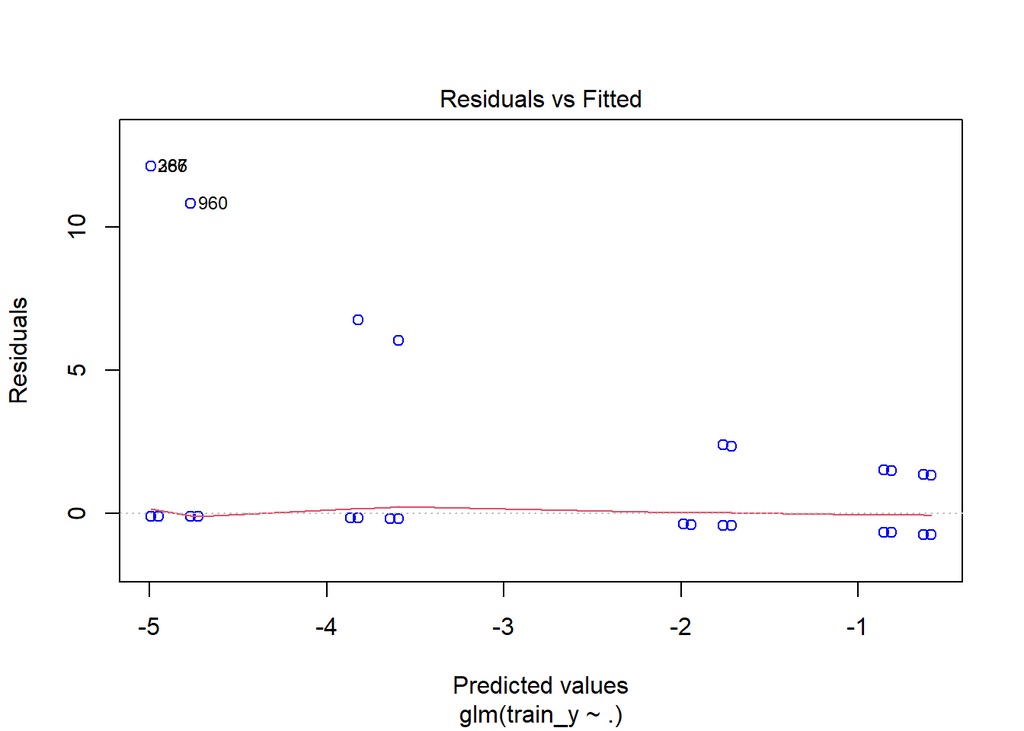

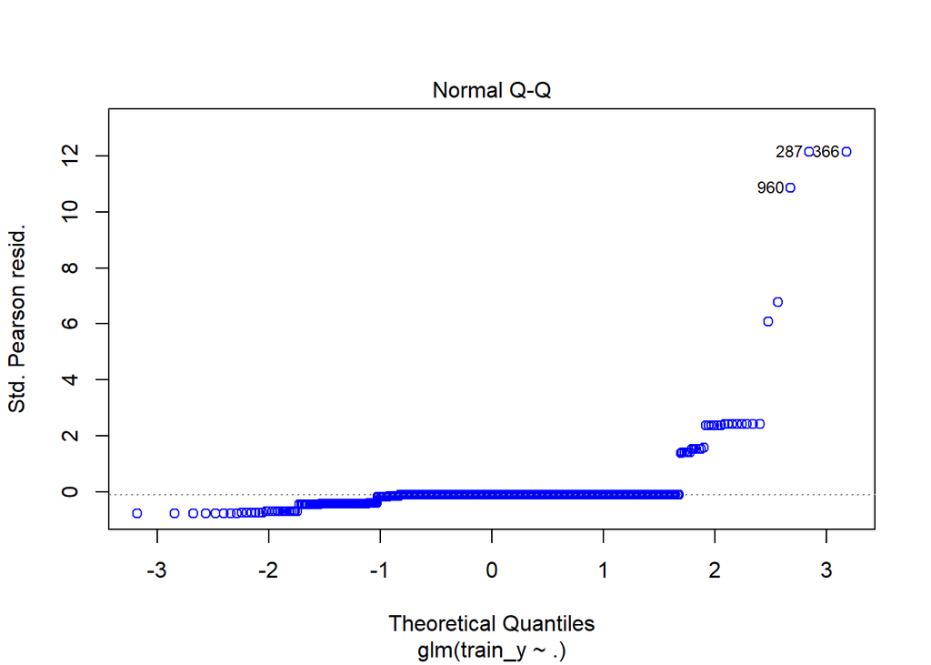

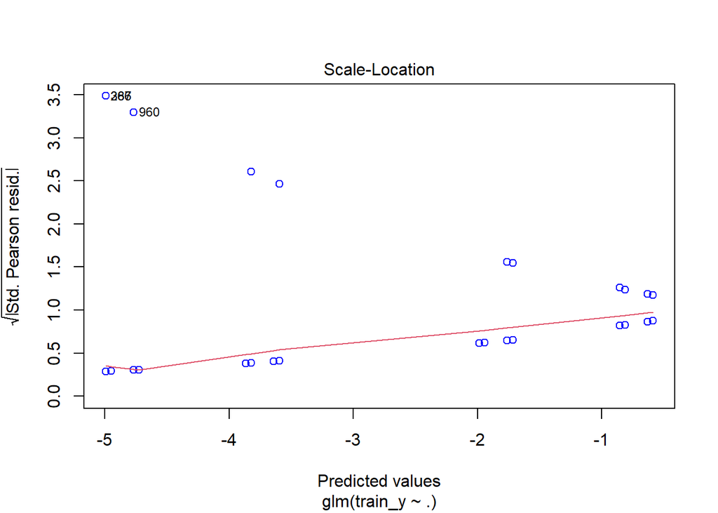

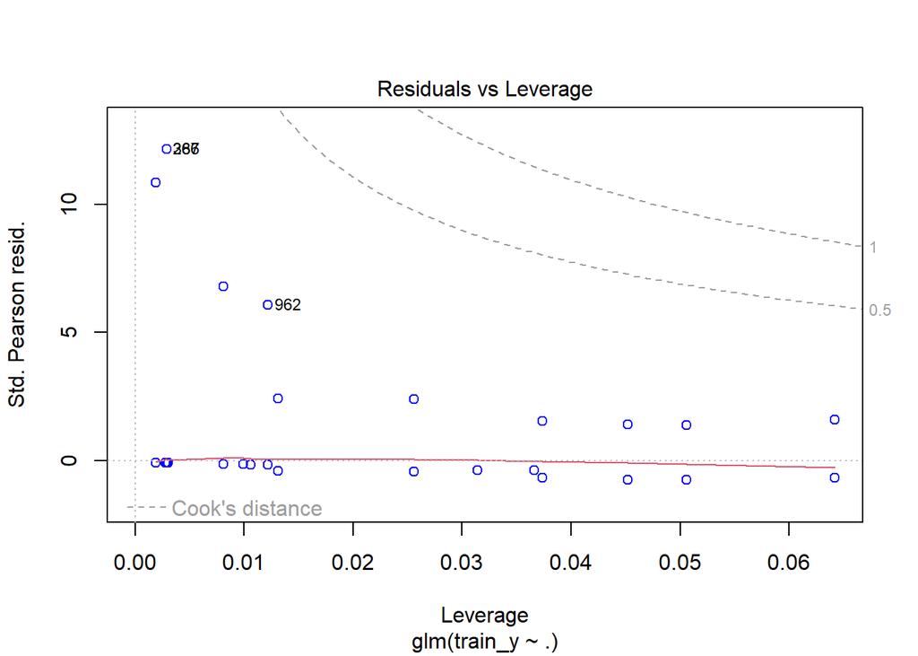

```r
suppressMessages(suppressWarnings(plot(fit1,col="blue")))
```

1. Residuals vs. Fitted Plot This plot illustrates the relationship between residuals and the fitted values of the binary logistic regression model. Residuals represent the differences between the observed and predicted values. The Y-axis displays the residuals, while the X-axis shows the fitted values. This plot helps assess whether there is a systematic pattern in the residuals relative to the fitted values. If the residuals are randomly scattered around zero with no discernible pattern, it indicates a good model fit. However, visible trends or patterns may suggest that the model does not adequately capture the data structure.

2. Normal Q-Q Plot This plot is used to evaluate whether the residuals follow a normal distribution. The Y-axis represents the observed quantiles of the residuals, while the X-axis shows the theoretical quantiles under the assumption of normality. If the residuals are normally distributed, the points will closely follow a diagonal line. Significant deviations from this line may indicate a violation of the normality assumption.
3. Scale-Location Plot This plot is a diagnostic tool for assessing the homogeneity of variance (homoscedasticity) in the residuals of a binary logistic regression model. Ideally, the points should be randomly dispersed around a horizontal line, indicating uniform variance. Patterns such as funnel or fan shapes may suggest heteroscedasticity — a violation of constant variance. If this occurs, it may be necessary to consider variable transformations, add explanatory variables, or explore alternative modeling techniques to improve the model fit.
4. Residuals vs. Leverage Plot This plot shows the relationship between standardized residuals and leverage values, which measure the influence of each observation on the model. Standardized residuals are residuals divided by their standard deviation. In the plot, these values are displayed on the Y-axis, while leverage scores appear on the X-axis. This visualization is useful for detecting outliers or influential points that may disproportionately affect the model. Observations that fall outside the typical range in terms of both residuals and leverage should be examined more closely and may need to be addressed or excluded to ensure model robustness.

```r
# Make predictions on test set
predictions1 <- predict(fit1, newdata = test, type = "response")

# Convert probabilities to class predictions
predicted_classes <- ifelse(predictions1 > 0.5, 1, 0)


# Convert predicted_classes and test_y to factors with the same levels
predicted_classes <- factor(predicted_classes, levels = levels(test_y))
test_y <- factor(test_y, levels = levels(predicted_classes))
```

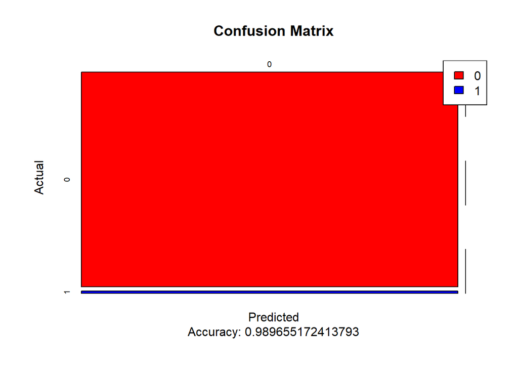

```r
# Accuracy
accuracy <- confusionMatrix(predicted_classes, test_y)$overall['Accuracy']

# Precision
precision <- confusionMatrix(predicted_classes,test_y)$byClass['Pos Pred Value']

# Recall
recall <- confusionMatrix(predicted_classes, test_y)$byClass['Sensitivity']

# F1 score
f1_score <- confusionMatrix(predicted_classes, test_y)$byClass['F1']

# Create the confusion matrix
conf_mat <- confusionMatrix(predicted_classes, test_y)

plot(conf_mat$table, col = c("#FF0000", "#0000FF"),
     main = "Confusion Matrix", xlab = "Predicted", ylab = "Actual",
     sub = paste("Accuracy:", conf_mat$overall['Accuracy']))

# Add legend
legend("topright", legend = rownames(conf_mat$table), fill = c("#FF0000", "#0000FF"))
```

```r
# Print the evaluation metrics
print(conf_mat)
```

```
## Confusion Matrix and Statistics
##
##           Reference
## Prediction   0   1
##          0 287   3
##          1   0   0
##
##                Accuracy : 0.9897
##                  95% CI : (0.9701, 0.9979)
##     No Information Rate : 0.9897
##     P-Value [Acc > NIR] : 0.6472
##
##                   Kappa : 0
##
##  Mcnemar's Test P-Value : 0.2482
##
##             Sensitivity : 1.0000
##             Specificity : 0.0000
##          Pos Pred Value : 0.9897
##          Neg Pred Value :    NaN
##              Prevalence : 0.9897
##          Detection Rate : 0.9897
##    Detection Prevalence : 1.0000
##       Balanced Accuracy : 0.5000
##
##        'Positive' Class : 0
##
```

```r
library(pROC)
```

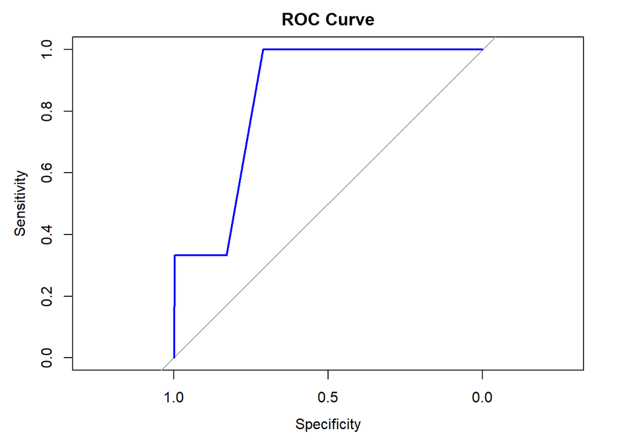

```r
# Calculate ROC curve
roc_obj <- roc(test_y, predictions1)
plot(roc_obj, main = "ROC Curve",col = "blue", lwd = 2)
```

Receiver Operating Characteristic (ROC) curve analysis is a graphical representation of the performance of a binary classification model. It is commonly used to evaluate the trade-off between the true positive rate (sensitivity) and the false positive rate (1 = specificity) at various classification thresholds. The ROC curve is created by plotting the true positive rate (TPR) on the y-axis against the false positive rate (FPR) on the x-axis. Each point on the curve represents a different classification threshold, which determines how the model assigns predicted class labels based on the predicted probabilities.

This is how ROC curve analysis works:

The classification model assigns predicted probabilities to each instance in the dataset. These probabilities represent the likelihood of belonging to the positive class.

Different classification thresholds can be applied to these predicted probabilities to determine the predicted class labels. By varying the threshold, you can adjust the trade-off between true positives and false positives.

For each threshold, the TPR (also known as sensitivity or recall) is calculated as the ratio of true positive predictions to the total number of true positive instances. It represents the model’s ability to correctly classify positive instances.

The False Positive Rate (FPR) is calculated as the ratio of false positive predictions to the total number of true negative instances. It represents the proportion of negative instances that are incorrectly classified as positive.

RoC Curve Plotting: The ROC curve is created by plotting the TPR against the FPR at various threshold values. Each point on the curve represents a different trade-off between sensitivity and specificity.

Area Under the Curve (AUC) is a metric that summarizes the overall performance of the classification model. It represents the probability that a randomly chosen positive instance will be classified higher than a randomly chosen negative instance by the model. AUC values range from 0 to 1, with a higher value indicating better classification performance.

Interpreting the ROC Curve:

The closer the curve is to the upper left corner, the better the model’s performance. A diagonal line from the bottom left to the top right represents a random classifier. Points above the diagonal line represent classifiers that are better than random. The AUC value provides a unique metric for comparing the performance of different models, with a higher value indicating better performance. Analyzing the ROC curve provides valuable insight into the performance of a binary classification model and helps you choose an appropriate classification threshold based on your specific sensitivity and specificity requirements.

### 2.- Random Forest(fit2)

```r
# library
library(randomForest)

# Train Random Forest model
fit2<- randomForest(train, train_y)

# Predict on test data
predictions2 <- predict(fit2, test)

# Evaluate model performance
accuracy <- sum(predictions2 == test_y) / length(predictions2)
```

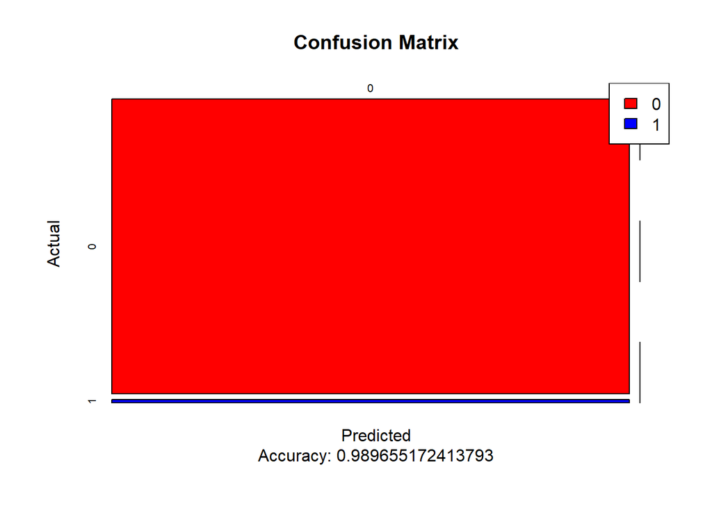

```r
# Create confusion matrix
conf_mat <- confusionMatrix(predictions2, test_y)

# Plot confusion matrix
plot(conf_mat$table, col = c("#FF0000", "#0000FF"),
     main = "Confusion Matrix", xlab = "Predicted", ylab = "Actual",
     sub = paste("Accuracy:", conf_mat$overall['Accuracy']))

# legend
legend("topright", legend = rownames(conf_mat$table), fill = c("#FF0000", "#0000FF"))
```

```r
# Print the evaluation metrics
print(conf_mat )
```

```
## Confusion Matrix and Statistics
##
##           Reference
## Prediction   0   1
##          0 287   3
##          1   0   0
##
##                Accuracy : 0.9897
##                  95% CI : (0.9701, 0.9979)
##     No Information Rate : 0.9897
##     P-Value [Acc > NIR] : 0.6472
##
##                   Kappa : 0
##
##  Mcnemar's Test P-Value : 0.2482
##
##             Sensitivity : 1.0000
##             Specificity : 0.0000
##          Pos Pred Value : 0.9897
##          Neg Pred Value :    NaN
##              Prevalence : 0.9897
##          Detection Rate : 0.9897
##    Detection Prevalence : 1.0000
##       Balanced Accuracy : 0.5000
##
##        'Positive' Class : 0
##
```

```r
library(pROC)

test_y <- as.numeric(as.character(test_y))
predictions2 <- as.numeric(as.character(predictions2))



# Create ROC object
roc_obj <- roc(test_y, predictions2)
```

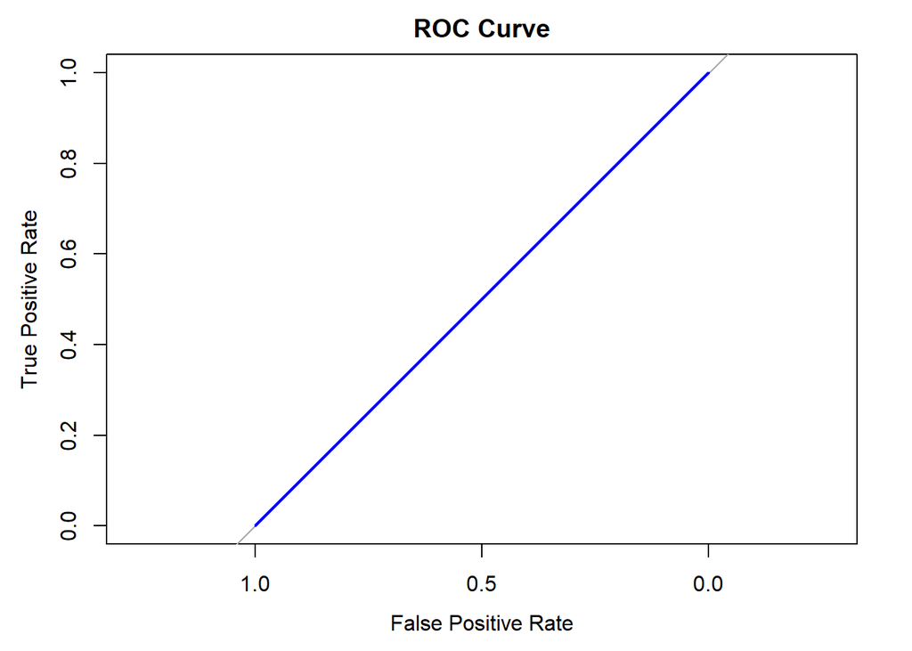

```r
# Plot ROC curve
plot(roc_obj, main = "ROC Curve",col = "blue", lwd = 2,  xlab = "False Positive Rate", ylab = "True Positive Rate")
```

If the ROC curve is a straight line along the diagonal, it indicates that the model cannot effectively discriminate between positive and negative classes.

This could be due to several reasons, such as:

Imbalanced data: If the dataset has an imbalanced class distribution, where one class has significantly fewer samples than the other, it can affect the model’s ability to learn and make accurate predictions. In such cases, you might consider using techniques such as minority class oversampling or majority class undersampling to address the class imbalance.

Insufficient features: The features you are using to train the random forest model may not have sufficient discriminatory power to distinguish between positive and negative classes. You could try selecting or designing more informative features that capture relevant patterns in the data.

Inappropriate model: It might not be the best choice for your particular problem. Different models have different strengths and weaknesses, and another algorithm may be more suitable.

Hyperparameter Tuning: The default hyperparameters used in the model may not be optimal for the data. You could try tuning the random forest model’s hyperparameters using techniques such as grid search or random search to find the optimal combination of hyperparameters.

### 3.- Regularization

In binary logistic regression, the objective is to predict the probability that an observation belongs to one of two possible classes. Regularization is commonly implemented by adding a penalty term to the cost function. There are two common types of regularization used in binary logistic regression: L1 (Lasso) regularization and L2 (Ridge) regularization. The model uses a logistic function to transform a linear combination of the predictor variables into a probability. The coefficients of this linear combination are estimated from the training data using the maximum likelihood method. The regularization parameter lambda controls the amount of penalty applied. A higher value of lambda produces a larger penalty and, therefore, smaller coefficients.

```r
# Load required library
#library(caret)

# Set the seed for reproducibility
set.seed(123)

# Split the data into train and test sets
train_idx <- sample(nrow(df), 0.7 * nrow(df))
train_data <- df[train_idx, ]
test_data <- df[-train_idx, ]

# Set the formula for the logistic regression model
formula <- Etiqueta_Eco ~ Club_Producto + Buenas_practicas + Sala_Reuniones + Restaurante

# Create the train control object for cross-validation
control <- trainControl(method = "cv", number = 12)

# Perform grid search for hyperparameter tuning
tune_grid <- expand.grid(alpha = c(0, 0.5, 1), lambda = c(0.001, 0.01, 0.1, 0.5, 1))


# Train the logistic regression model using glmnet
modelo <- train(formula, data = train_data, method = "glmnet", trControl = control, tuneGrid = tune_grid)
print(modelo)
```

```
## glmnet
##
## 675 samples
##   4 predictor
##
## No pre-processing
## Resampling: Cross-Validated (12 fold)
## Summary of sample sizes: 619, 619, 619, 618, 619, 618, ...
## Resampling results across tuning parameters:
##
##   alpha  lambda  RMSE       Rsquared   MAE
##   0.0    0.001   0.1604489  0.1724189  0.05980151
##   0.0    0.010   0.1603465  0.1727164  0.05961124
##   0.0    0.100   0.1589477  0.1760996  0.05812729
##   0.0    0.500   0.1601722  0.1780971  0.06077643
##   0.0    1.000   0.1615391  0.1781849  0.06172897
##   0.5    0.001   0.1606881  0.1717421  0.05969317
##   0.5    0.010   0.1602237  0.1707887  0.05676391
##   0.5    0.100   0.1631900  0.1626655  0.06241435
##   0.5    0.500   0.1645689        NaN  0.06312531
##   0.5    1.000   0.1645689        NaN  0.06312531
##   1.0    0.001   0.1606795  0.1713907  0.05928627
##   1.0    0.010   0.1600284  0.1689986  0.05719065
##   1.0    0.100   0.1645689        NaN  0.06312531
##   1.0    0.500   0.1645689        NaN  0.06312531
##   1.0    1.000   0.1645689        NaN  0.06312531
##
## RMSE was used to select the optimal model using the smallest value.
## The final values used for the model were alpha = 0 and lambda = 0.1.
```

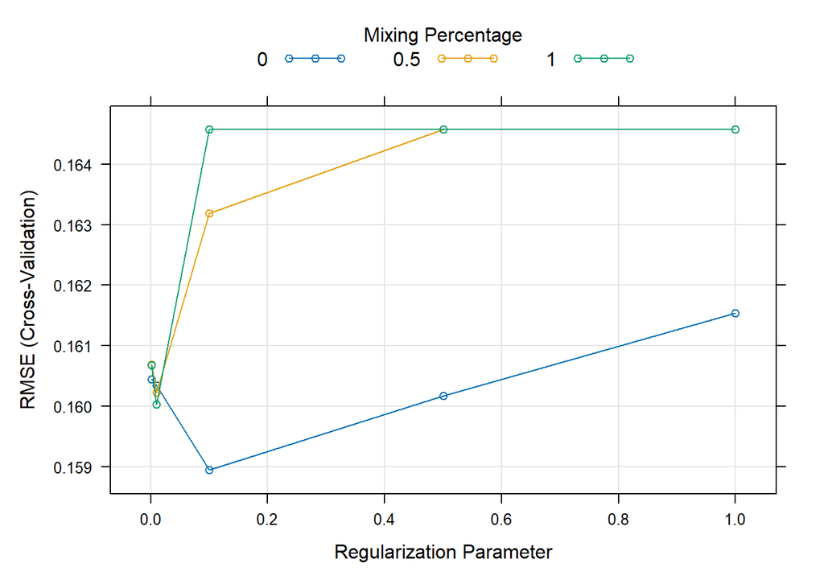

```r
suppressMessages(suppressWarnings(plot(modelo)))
```

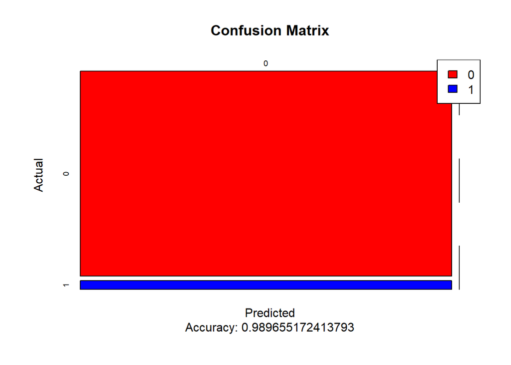

```r
# Make predictions on the test dataset
predictions <- predict(modelo, newdata = test_data, type = "raw")

# Convert predictions to binary values (0 or 1) based on a threshold
threshold <- 0.5
binary_predictions <- ifelse(predictions > threshold, 1, 0)

# Create a factor variable for the predicted values with consistent levels
predicted_factor <- factor(binary_predictions, levels = c(0, 1))

# Create a factor variable for the actual values with consistent levels
actual_factor <- factor(test_data$Etiqueta_Eco, levels = c(0, 1))

# Calculate evaluation metrics
confusion_matrix <- confusionMatrix(predicted_factor, actual_factor)
accuracy <- confusion_matrix$overall["Accuracy"]
precision <- confusion_matrix$byClass["Pos Pred Value"]
recall <- confusion_matrix$byClass["Sensitivity"]
f1_score <- confusion_matrix$byClass["F1"]


plot(confusion_matrix$table, col = c("#FF0000", "#0000FF"),
     main = "Confusion Matrix", xlab = "Predicted", ylab = "Actual",
     sub = paste("Accuracy:", conf_mat$overall['Accuracy']))

# Add legend
legend("topright", legend = rownames(conf_mat$table), fill = c("#FF0000", "#0000FF"))
```

```r
# Print the evaluation metrics
print(confusion_matrix)
```

```
## Confusion Matrix and Statistics
##
##           Reference
## Prediction   0   1
##          0 278  12
##          1   0   0
##
##                Accuracy : 0.9586
##                  95% CI : (0.9288, 0.9784)
##     No Information Rate : 0.9586
##     P-Value [Acc > NIR] : 0.575982
##
##                   Kappa : 0
##
##  Mcnemar's Test P-Value : 0.001496
##
##             Sensitivity : 1.0000
##             Specificity : 0.0000
##          Pos Pred Value : 0.9586
##          Neg Pred Value :    NaN
##              Prevalence : 0.9586
##          Detection Rate : 0.9586
##    Detection Prevalence : 1.0000
##       Balanced Accuracy : 0.5000
##
##        'Positive' Class : 0
##
```

```r
cat("\n")
```

```r
cat("Accuracy:", accuracy, "\n")
```

```
## Accuracy: 0.9586207
```

```r
cat("Precision:", precision, "\n")
```

```
## Precision: 0.9586207
```

```r
cat("Recall:", recall, "\n")
```

```
## Recall: 1
```

```r
cat("F1-Score:", f1_score, "\n")
```

```
## F1-Score: 0.9788732
```

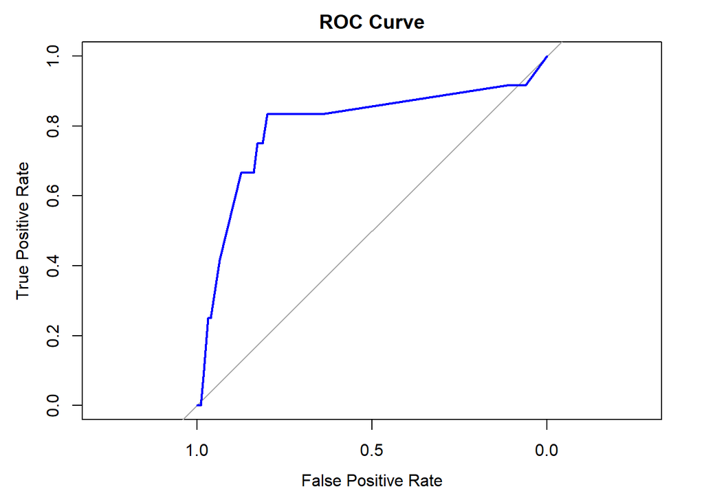

```r
# Create the ROC curve
roc <- roc(as.numeric(actual_factor) - 1, predictions)
roc_plot <- plot(roc, main = "ROC Curve",col = "blue", lwd = 2, xlab = "False Positive Rate", ylab = "True Positive Rate")
```

```r
# Display the ROC plot
print(roc_plot)
```

```
##
## Call:
## roc.default(response = as.numeric(actual_factor) - 1, predictor = predictions)
##
## Data: predictions in 278 controls (as.numeric(actual_factor) - 1 0) < 12 cases (as.numeric(actual_factor) - 1 1).
## Area under the curve: 0.7995
```

- McNemar’s Test P-Value: The McNemar test is used to compare the proportions of misclassification errors between two models or algorithms. A low p-value (less than the established significance level, usually 0.05) indicates a significant difference in the proportions of misclassification errors between the models compared. The model obtained 0.001496.
- Sensitivity: This is the proportion of true positives (correctly classified positive cases) relative to the total number of positive cases in the data. In this case, the sensitivity is 1.0000, indicating that the model correctly classified all positive cases.
- Specificity: This is the proportion of true negatives (correctly classified negative controls) relative to the total number of negative cases in the data. In this case, the specificity is 0.0000, indicating that the model did not correctly classify any of the negative controls.
- Positive Predictive Value: This is the proportion of correctly classified positive cases out of the total number of cases classified as positive by the model. In this case, the positive predictive value is 0.9586, indicating that 95.86% of the positive predictions made by the model were correct.
- Neg Pred Value: This is not a value (NaN), indicating that the negative predictive value cannot be calculated due to a lack of correctly classified negative controls. Prevalence: This is the proportion of positive cases in the data. In this case, the prevalence is 0.9586, indicating that approximately 95.86% of cases are positive.
- Detection Rate: This is the proportion of correctly classified positive cases out of the total number of positive cases. In this case, the detection rate is 0.9586, indicating that 95.86% of positive cases were correctly detected by the model.
- Detection Prevalence: This is the proportion of cases classified as positive by the model out of the total number of cases. In this case, the detection prevalence is 1.0000, indicating that 100% of cases were classified as positive by the model.
- Balanced Accuracy: This is the arithmetic average of the sensitivity and specificity. In this case, the balanced accuracy is 0.5000, indicating mediocre performance of the model in classifying both types of cases.

```r
# Load the ROSE package
library(ROSE)
# Set the seed for reproducibility
set.seed(123)


# Split the data into train and test sets
train_idx <- sample(nrow(df), 0.7 * nrow(df))
train_data <- df[train_idx, ]
test_data <- df[-train_idx, ]


# Balance the data using ROSE
balanced_data <- ROSE(Etiqueta_Eco ~ ., data = train_data, p = 0.5)$data

# Set the formula for the logistic regression model
formula <- Etiqueta_Eco ~ Club_Producto + Buenas_practicas + Sala_Reuniones + Restaurante

# Create the train control object for cross-validation
control <- trainControl(method = "cv", number = 12)

# Perform grid search for hyperparameter tuning
tune_grid <- expand.grid(alpha = c(0, 0.5, 1), lambda = c(0.001, 0.01, 0.1, 0.5, 1))


# Train the logistic regression model using glmnet
modelo <- train(formula, data = balanced_data, method = "glmnet", trControl = control, tuneGrid = tune_grid)
print(modelo)
```

```
## glmnet
##
## 675 samples
##   4 predictor
##
## No pre-processing
## Resampling: Cross-Validated (12 fold)
## Summary of sample sizes: 618, 618, 619, 619, 619, 619, ...
## Resampling results across tuning parameters:
##
##   alpha  lambda  RMSE       Rsquared   MAE
##   0.0    0.001   0.3642965  0.4839792  0.2838876
##   0.0    0.010   0.3642965  0.4839792  0.2838876
##   0.0    0.100   0.3674722  0.4826305  0.3004835
##   0.0    0.500   0.3946658  0.4752986  0.3676061
##   0.0    1.000   0.4195978  0.4710521  0.4068495
##   0.5    0.001   0.3637226  0.4842540  0.2756750
##   0.5    0.010   0.3639654  0.4840440  0.2790380
##   0.5    0.100   0.3753509  0.4768528  0.3227420
##   0.5    0.500   0.4644829  0.4693406  0.4621623
##   0.5    1.000   0.5002731        NaN  0.4998504
##   1.0    0.001   0.3637258  0.4842443  0.2754487
##   1.0    0.010   0.3643569  0.4832874  0.2807179
##   1.0    0.100   0.3842695  0.4693406  0.3427787
##   1.0    0.500   0.5002731        NaN  0.4998504
##   1.0    1.000   0.5002731        NaN  0.4998504
##
## RMSE was used to select the optimal model using the smallest value.
## The final values used for the model were alpha = 0.5 and lambda = 0.001.
```

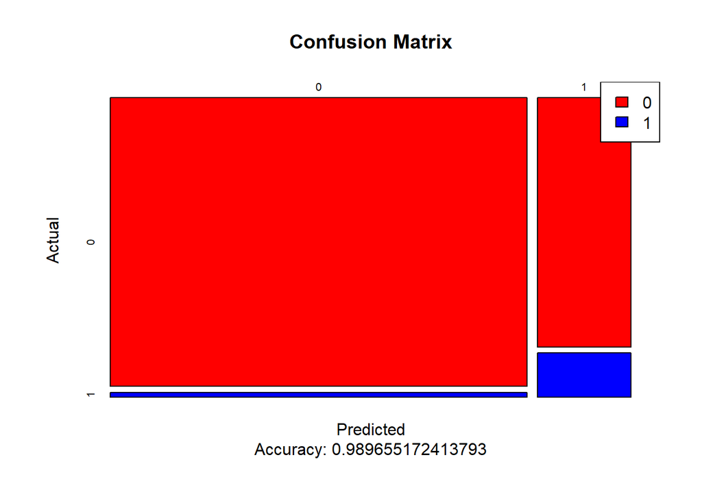

```r
# Make predictions on the test dataset
predictions <- predict(modelo, newdata = test_data, type = "raw")

# Convert predictions to binary values (0 or 1) based on a threshold
threshold <- 0.5
binary_predictions <- ifelse(predictions > threshold, 1, 0)

# Create a factor variable for the predicted values with consistent levels
predicted_factor <- factor(binary_predictions, levels = c(0, 1))

# Create a factor variable for the actual values with consistent levels
actual_factor <- factor(test_data$Etiqueta_Eco, levels = c(0, 1))

# Calculate evaluation metrics
confusion_matrix <- confusionMatrix(predicted_factor, actual_factor)
accuracy <- confusion_matrix$overall["Accuracy"]
precision <- confusion_matrix$byClass["Pos Pred Value"]
recall <- confusion_matrix$byClass["Sensitivity"]
f1_score <- confusion_matrix$byClass["F1"]


plot(confusion_matrix$table, col = c("#FF0000", "#0000FF"),
     main = "Confusion Matrix", xlab = "Predicted", ylab = "Actual",
     sub = paste("Accuracy:", conf_mat$overall['Accuracy']))

# Add legend
legend("topright", legend = rownames(conf_mat$table), fill = c("#FF0000", "#0000FF"))
```

```r
# Print the evaluation metrics
print(confusion_matrix)
```

```
## Confusion Matrix and Statistics
##
##           Reference
## Prediction   0   1
##          0 233   4
##          1  45   8
##
##                Accuracy : 0.831
##                  95% CI : (0.7828, 0.8723)
##     No Information Rate : 0.9586
##     P-Value [Acc > NIR] : 1
##
##                   Kappa : 0.1916
##
##  Mcnemar's Test P-Value : 1.102e-08
##
##             Sensitivity : 0.8381
##             Specificity : 0.6667
##          Pos Pred Value : 0.9831
##          Neg Pred Value : 0.1509
##              Prevalence : 0.9586
##          Detection Rate : 0.8034
##    Detection Prevalence : 0.8172
##       Balanced Accuracy : 0.7524
##
##        'Positive' Class : 0
##
```

```r
cat("\n")
```

```r
cat("Accuracy:", accuracy, "\n")
```

```
## Accuracy: 0.8310345
```

```r
cat("Precision:", precision, "\n")
```

```
## Precision: 0.9831224
```

```r
cat("Recall:", recall, "\n")
```

```
## Recall: 0.8381295
```

```r
cat("F1-Score:", f1_score, "\n")
```

```
## F1-Score: 0.9048544
```

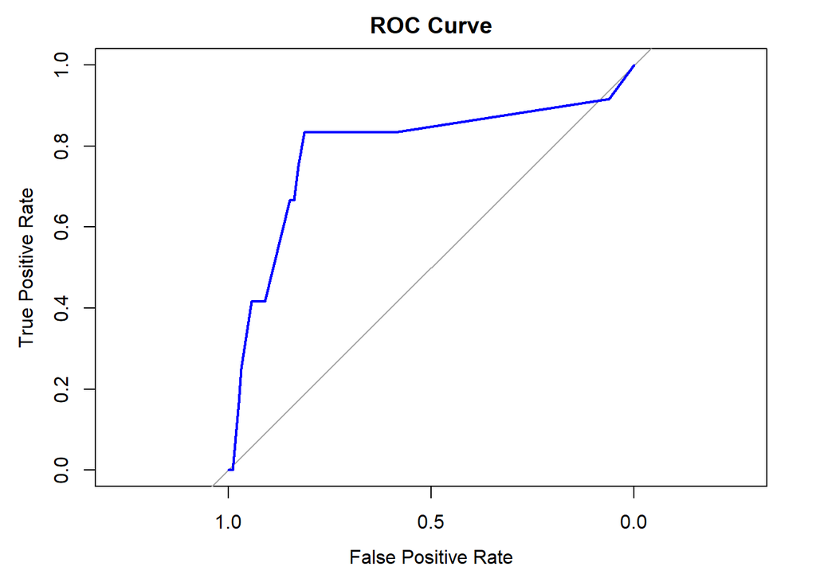

```r
# Create the ROC curve
roc <- roc(as.numeric(actual_factor) - 1, predictions)
roc_plot <- plot(roc, main = "ROC Curve",col = "blue", lwd = 2, xlab = "False Positive Rate", ylab = "True Positive Rate")
```

```r
# Display the ROC plot
print(roc_plot)
```

```
##
## Call:
## roc.default(response = as.numeric(actual_factor) - 1, predictor = predictions)
##
## Data: predictions in 278 controls (as.numeric(actual_factor) - 1 0) < 12 cases (as.numeric(actual_factor) - 1 1).
## Area under the curve: 0.7911
```

### 📈 Predictive Model Overview

[figure not shown]

### ⚙️ Model Training Pipeline

This chart illustrates the R-based implementation pipeline including formula specification, ROSE class balancing, cross-validation strategy, grid search for hyperparameter tuning, and model fitting with `glmnet`.

[figure not shown]

Fuente: https://www.datacamp.com/tutorial/pca-analysis-r https://towardsdatascience.com/implementing-binary-logistic-regression-in-r-7d802a9d98fe https://stats.stackexchange.com/questions/126996/what-if-response-variable-is-yes-or-no-in-r https://rpubs.com/Joaquin_AR/229736 https://towardsdatascience.com/implementing-binary-logistic-regression-in-r-7d802a9d98fe https://www.analyticsvidhya.com/blog/2020/06/auc-roc-curve-machine-learning/ https://www.digitalocean.com/community/tutorials/plot-roc-curve-r-programming https://support.minitab.com/es-mx/minitab/20/help-and-how-to/statistical-modeling/regression/how-to/fit-regression-model/interpret-the-results/all-statistics-and-graphs/residual-plots/ https://rstudio-pubs-static.s3.amazonaws.com/913247_38e820858d444638b1bc8253a4202bb4.html https://fervilber.github.io/Aprendizaje-supervisado-en-R/glm.html